# Lab 5: Count Regression

Physician Visits Among Older Adults

Author

Rayan Grira

# Part 1: Configure the project and examine the data

## Load packages and prepare the data

The outcome is the number of physician office visits. Predictors are the number of chronic conditions, self-perceived health, gender, years of education, and private insurance coverage.

The reference groups are average health, male, and no private insurance.

## Explore the data

Descriptive Statistics for Physician Office Visits

| N | Mean | Variance | Proportion of zeros | Maximum |
| --- | --- | --- | --- | --- |
| 4,406 | 5.774 | 45.687 | 0.155 | 89 |

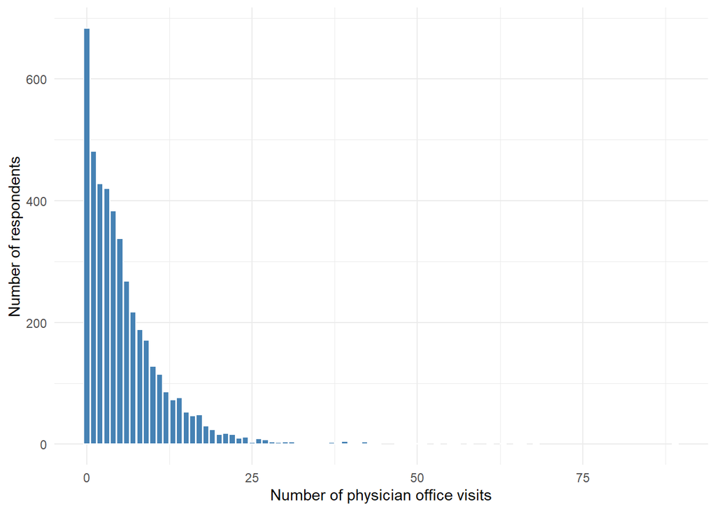

Distribution of physician office visits.

Physician office visits are a count outcome: values are non-negative whole numbers. Among 4406 respondents, the mean number of visits was 5.77, and the variance was 45.69. The variance-to-mean ratio was 7.91. Overall, 15.5% of respondents reported no visits, and the maximum was 89 visits.

# Part 2: Specify competing count models

## Why not a linear model?

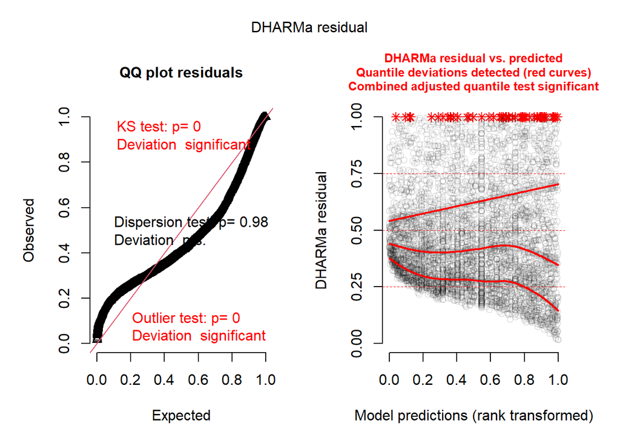

DHARMa residual diagnostics for the Gaussian model.

The Gaussian model showed substantial lack of fit. The DHARMa QQ plot strayed far from the diagonal, and the uniformity and outlier tests were significant. The residual-versus-predicted plot also showed systematic quantile deviations, indicating that the residual distribution varied across fitted values. Even though the dispersion test was not significant, this did not resolve the other diagnostic problems. A Gaussian model also assigns probability to negative and non-integer outcomes, whereas physician visits are non-negative counts, and its constant conditional variance assumption may be unsuitable for this outcome. These findings motivate evaluating count-regression models.

## Specify three nested Poisson models

## Compare the Poisson models

Comparison of Nested Poisson Models

| Model | Df | AIC | BIC | logLik | deviance | Chisq | Chi Df | Pr(>Chisq) |
| --- | --- | --- | --- | --- | --- | --- | --- | --- |
| m0_pois | 1 | 39720.34 | 39726.73 | -19859.17 | 39718.34 | NA | NA | NA |
| m1_pois | 2 | 37546.91 | 37559.69 | -18771.46 | 37542.91 | 2175.4279 | 1 | 0.000000e+00 |
| m2_pois | 7 | 36596.99 | 36641.72 | -18291.49 | 36582.99 | 959.9239 | 5 | 2.849021e-205 |

Adding chronic conditions to the intercept-only Poisson model significantly improved fit, χ²(1) = 2175.43, *p* < .001. This comparison shows that including chronic conditions improves the model relative to predicting the same expected number of visits for every respondent.

Adding health, gender, schooling, and private insurance to the chronic-only model further improved fit, χ²(5) = 959.92, *p* < .001. This comparison tests the additional predictors collectively rather than stating that every added predictor is individually significant.

The full model M2 was therefore selected as the preferred model among the three Poisson candidates. However, improved fit relative to simpler Poisson models does not establish that M2 adequately describes the data. Its dispersion and ability to reproduce the observed zeros are evaluated next using DHARMa diagnostics.

# Part 3: Evaluate the Poisson model

## Simulate residuals

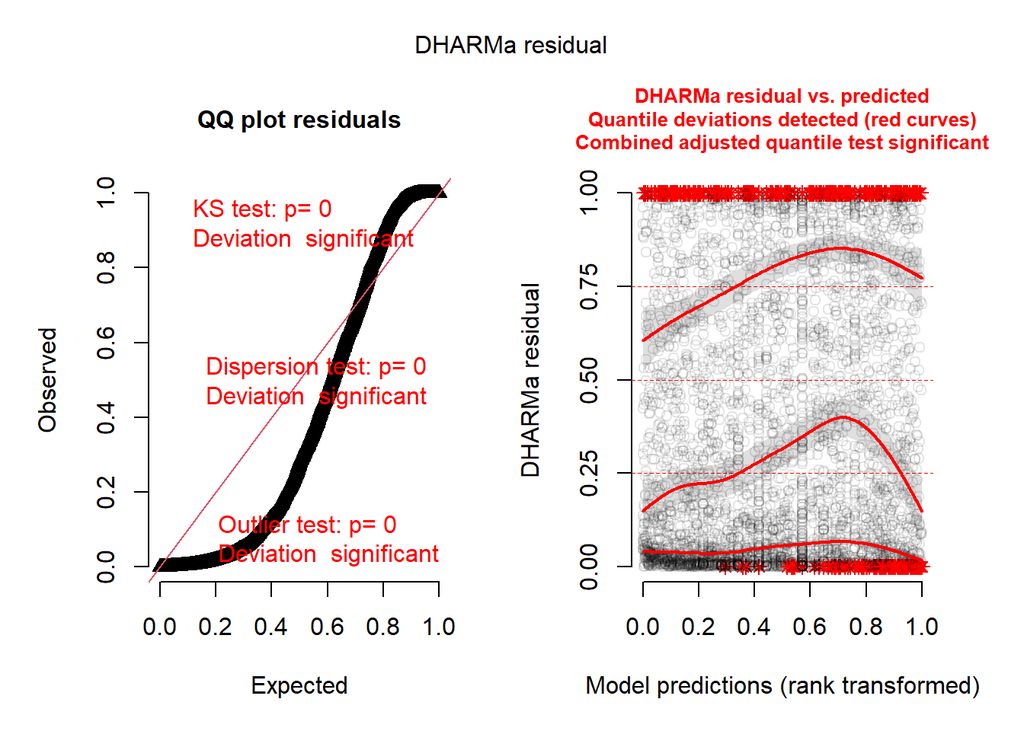

DHARMa residual diagnostics for the full Poisson model.

## Test for dispersion and excess zeros

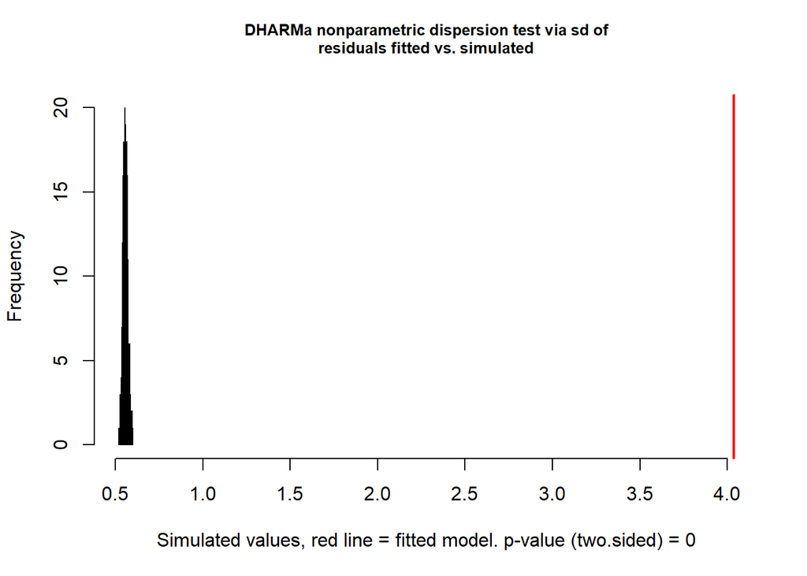

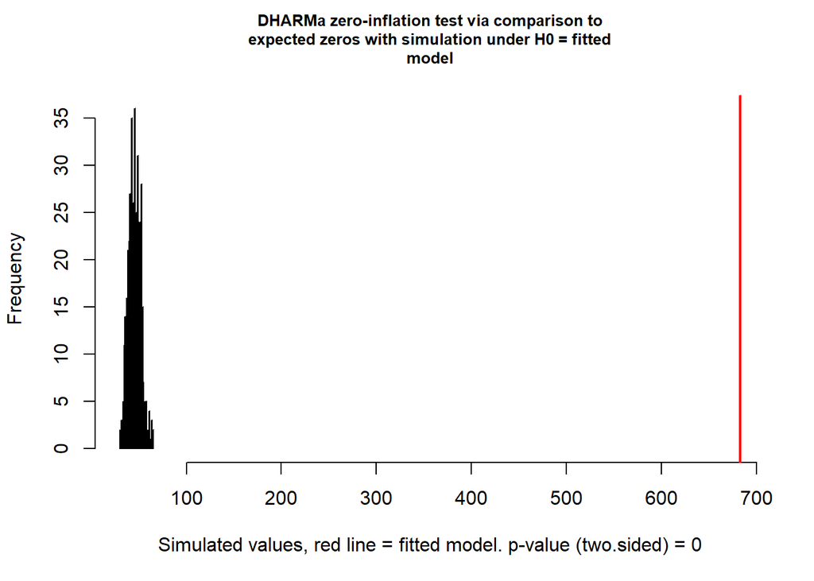

```
    DHARMa nonparametric dispersion test via sd of residuals fitted vs.
    simulated

data:  simulationOutput
dispersion = 7.2457, p-value < 2.2e-16
alternative hypothesis: two.sided
```

```
    DHARMa zero-inflation test via comparison to expected zeros with
    simulation under H0 = fitted model

data:  simulationOutput
ratioObsSim = 14.906, p-value < 2.2e-16
alternative hypothesis: two.sided
```

The Poisson DHARMa QQ plot did not follow the diagonal reference line, indicating that the simulated residuals did not follow the expected uniform distribution. The uniformity, dispersion, and outlier tests were significant. In the residual-versus-predicted panel, the red quantile curves departed systematically from their horizontal reference lines, and the combined adjusted quantile test was significant. Together, these patterns show that the full Poisson model did not reproduce the observed outcome distribution.

## Interpret the Poisson diagnostics

The full Poisson model showed significant overdispersion (DHARMa dispersion ratio = 7.25, *p* < .001). The observed number of zeros was 14.91 times the number expected under the fitted model (*p* < .001). These results indicate that the Poisson model does not adequately capture the variability and zeros in the outcome. Overdispersion can lead to underestimated standard errors, overly narrow confidence intervals, and overly small p-values. However, excess zeros relative to the Poisson model do not necessarily imply a separate zero-generating process. A negative binomial model will therefore be evaluated before considering a zero-inflated or hurdle model.

# Part 4: Fit and evaluate a negative binomial model

## Estimate the NB2 model

## Compare the Poisson and NB2 models

Comparison of Full Poisson and Negative Binomial Models

| Model | Df | AIC | BIC | logLik | deviance | Chisq | Chi Df | Pr(>Chisq) |
| --- | --- | --- | --- | --- | --- | --- | --- | --- |
| m2_pois | 7 | 36596.99 | 36641.72 | -18291.49 | 36582.99 | NA | NA | NA |
| m_nb | 8 | 24469.91 | 24521.03 | -12226.95 | 24453.91 | 12129.08 | 1 | 0 |

## Re-check the NB2 model with DHARMa

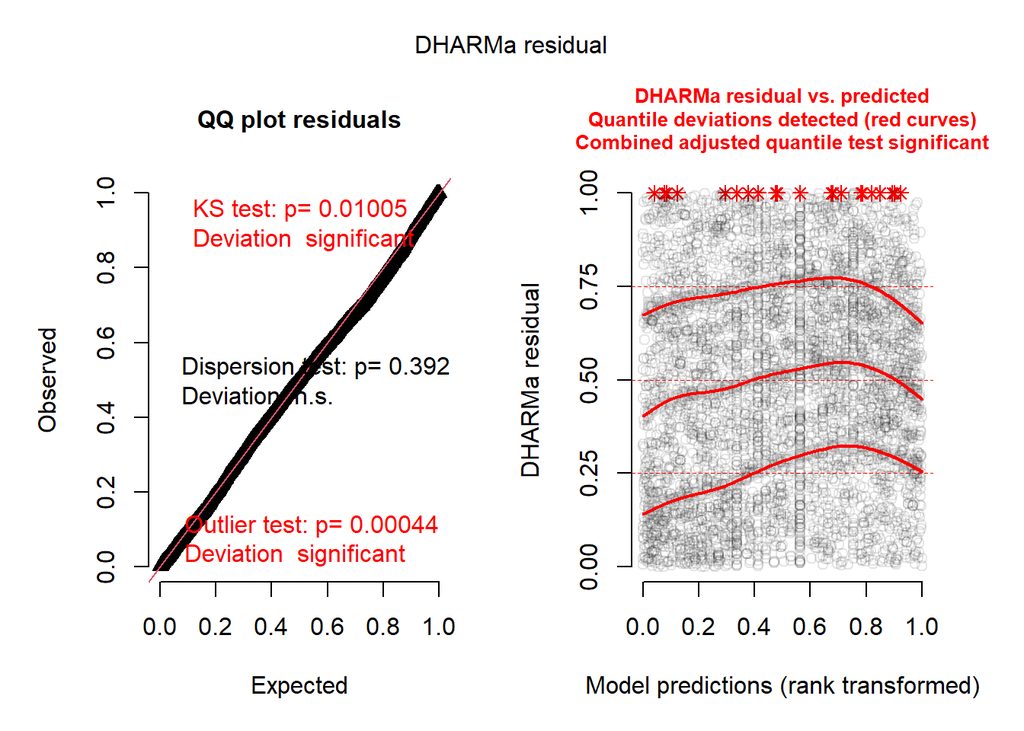

DHARMa residual diagnostics for the NB2 model.

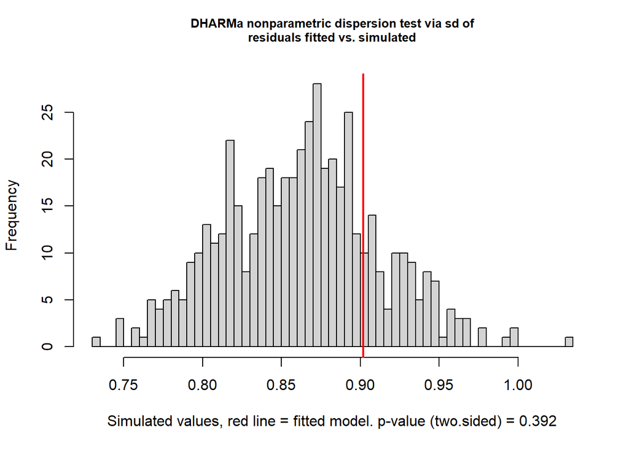

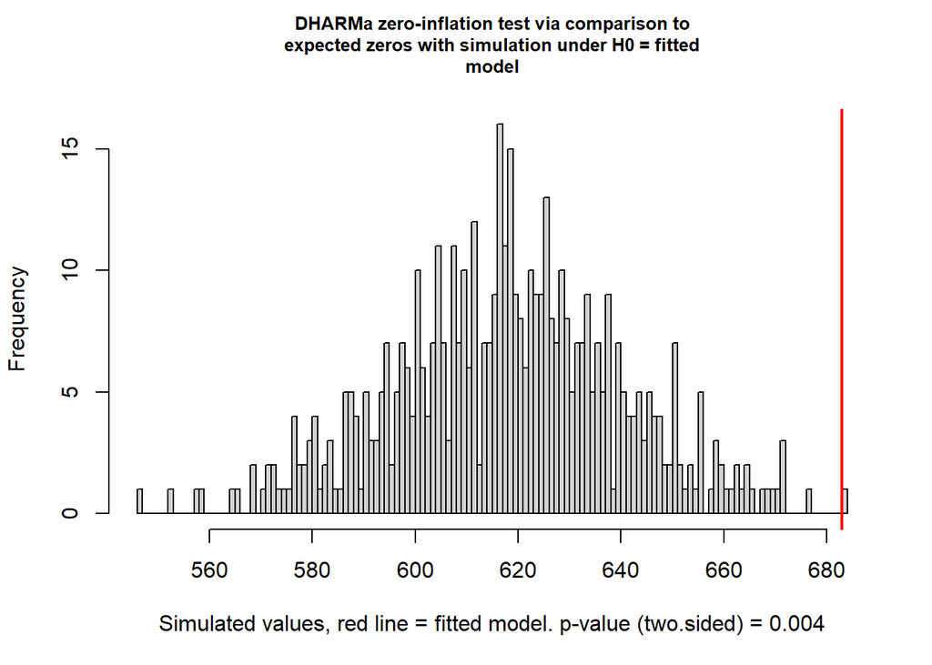

```
    DHARMa nonparametric dispersion test via sd of residuals fitted vs.
    simulated

data:  simulationOutput
dispersion = 1.0456, p-value = 0.392
alternative hypothesis: two.sided
```

```
    DHARMa zero-inflation test via comparison to expected zeros with
    simulation under H0 = fitted model

data:  simulationOutput
ratioObsSim = 1.1044, p-value = 0.004
alternative hypothesis: two.sided
```

However, the NB2 model continued to under predict zeros (observed/expected ratio = 1.1, *p* = 0.004). Although this mismatch was much smaller than under Poisson, the observed number of zeros remained approximately 10.44% greater than expected. So, Zero-inflated and hurdle negative binomial models will be evaluated.

## Visualize predicted counts

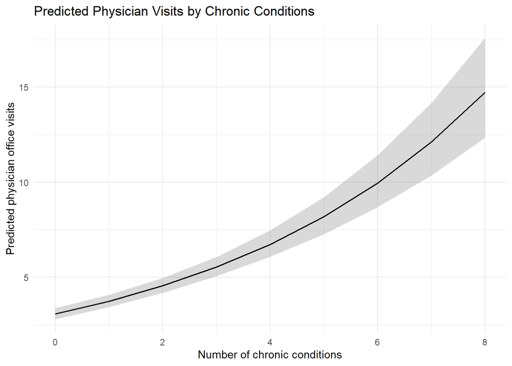

Predicted physician visits by number of chronic conditions under NB2.

The predicted relationship curves because the NB2 model uses a log link, which makes the predicted relationship curved on the count scale. A one-unit increase in chronic conditions adds a constant amount to the log expected count, corresponding to a multiplicative change in the expected number of visits.

# Part 5: Decide whether the zeros need their own model

## Decide whether to investigate a separate process for zeros

The NB2 model heavily improved on the Poisson model, but it still under predicted the number of zeros. Its observed-to-expected zero ratio was 1.1, with *p* = 0.004. So, zero-inflated and hurdle negative binomial models were fitted for comparison with NB2.

## Fit the zero-inflated negative binomial model

## Fit the hurdle negative binomial model

## Compare NB2 with the zero-inflated model

```
Data: data
Models:
m_nb: visits ~ chronic + health + gender + school + insurance, zi=~0, disp=~1
m_zinb: visits ~ chronic + health + gender + school + insurance, zi=~chronic + health + gender + school + insurance, disp=~1
       Df   AIC   BIC logLik deviance  Chisq Chi Df Pr(>Chisq)
m_nb    8 24470 24521 -12227    24454
m_zinb 15 24341 24437 -12155    24311 143.14      7  < 2.2e-16 ***
---
Signif. codes:  0 '***' 0.001 '**' 0.01 '*' 0.05 '.' 0.1 ' ' 1
```

## Compare all three models using AIC and BIC

AIC Comparison of Models

| Model | df | AIC |
| --- | --- | --- |
| m_nb | 8 | 24469.91 |
| m_zinb | 15 | 24340.77 |
| m_hurdle | 15 | 24330.41 |

BIC Comparison of Models

| Model | df | BIC |
| --- | --- | --- |
| m_nb | 8 | 24521.03 |
| m_zinb | 15 | 24436.63 |
| m_hurdle | 15 | 24426.27 |

## Evaluate the model comparisons

The zero-inflated negative binomial model improved fit relative to NB2 in the likelihood-ratio comparison, χ²(7) = 143.14, *p* < .001. This test involves a boundary case, so it was considered alongside the information criteria and residual diagnostics.

## Re-check the hurdle model with DHARMa

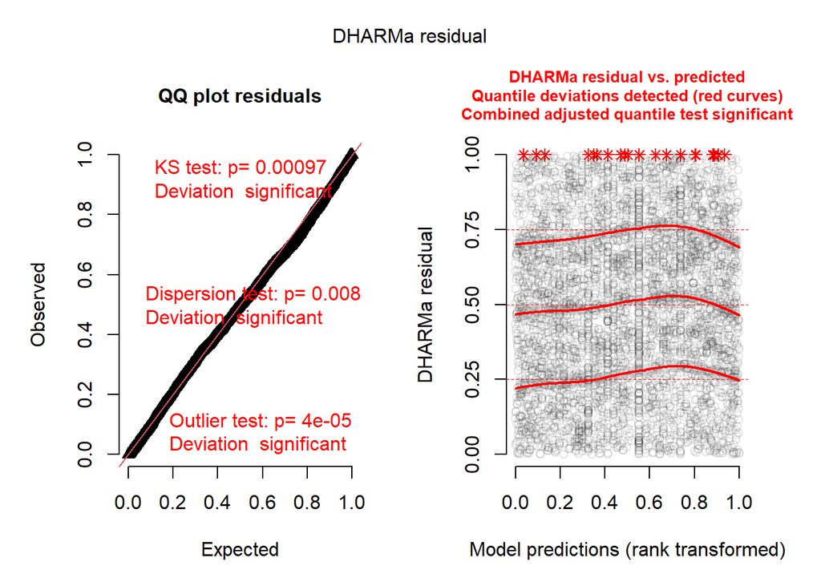

DHARMa residual diagnostics for the hurdle negative binomial model.

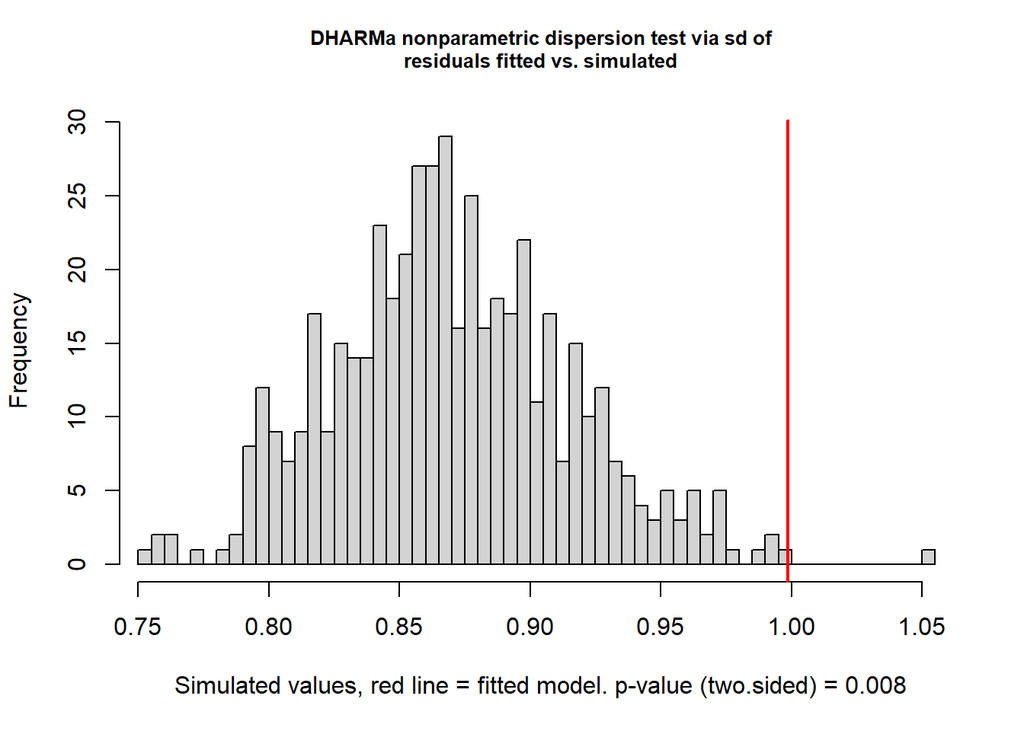

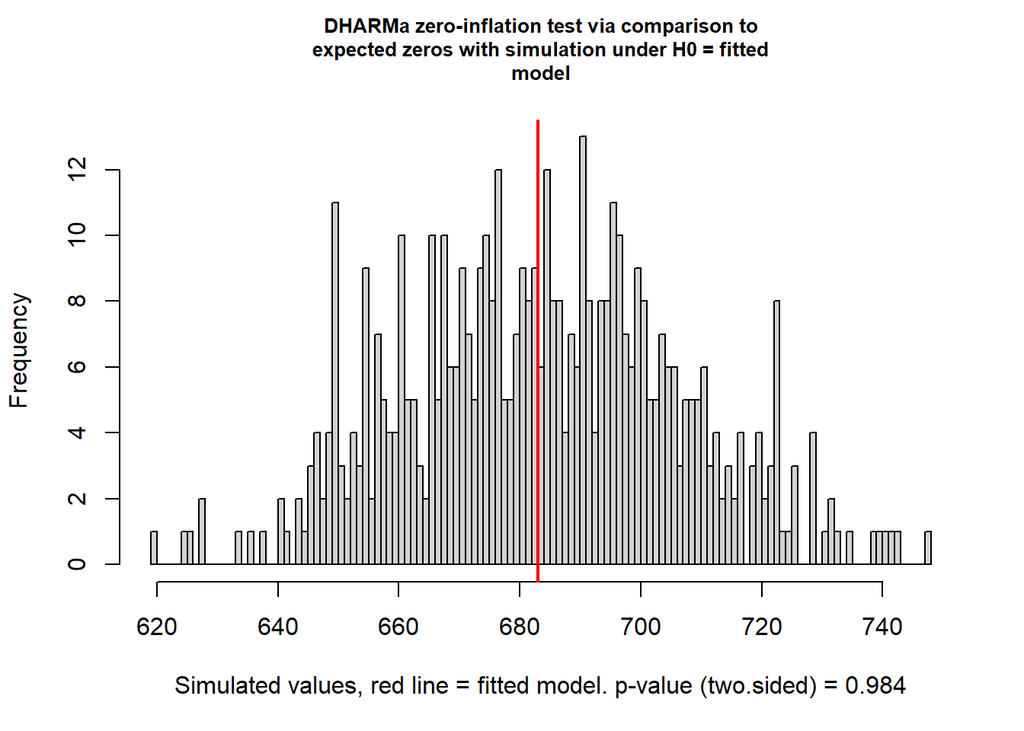

```
    DHARMa nonparametric dispersion test via sd of residuals fitted vs.
    simulated

data:  simulationOutput
dispersion = 1.1477, p-value = 0.008
alternative hypothesis: two.sided
```

```
    DHARMa zero-inflation test via comparison to expected zeros with
    simulation under H0 = fitted model

data:  simulationOutput
ratioObsSim = 0.99827, p-value = 0.984
alternative hypothesis: two.sided
```

The hurdle negative binomial model reproduced the overall number of zeros well (observed/expected ratio = 0.998, *p* = 0.984). But, the dispersion test remained significant (ratio = 1.148, *p* = 0.008), indicating residual overdispersion. So, although the hurdle model had the lowest AIC and BIC among the candidates, its diagnostics did not indicate a fully adequate fit. I also examined the ZINB model before making the final model choice.

## Examine ZINB diagnostics

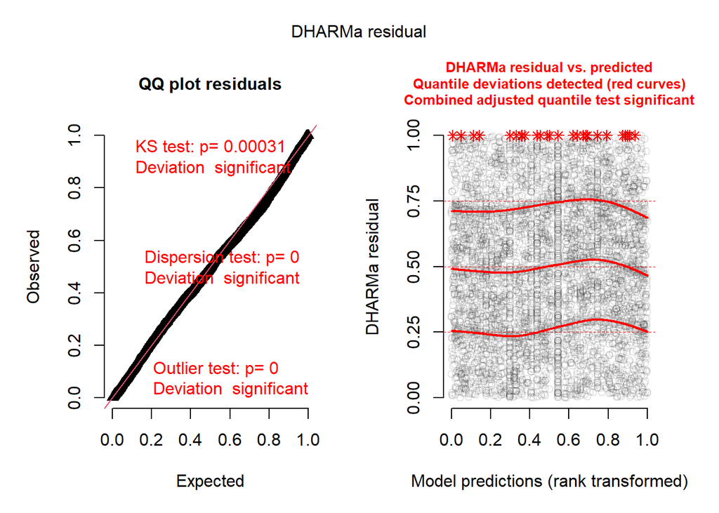

DHARMa residual diagnostics for the ZINB model.

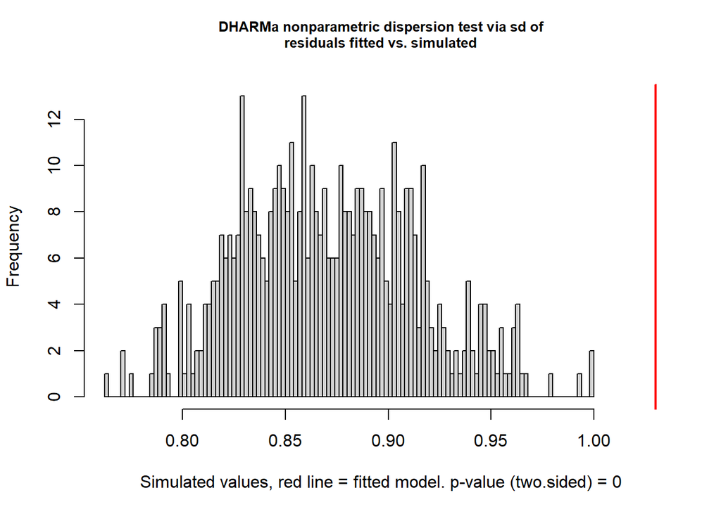

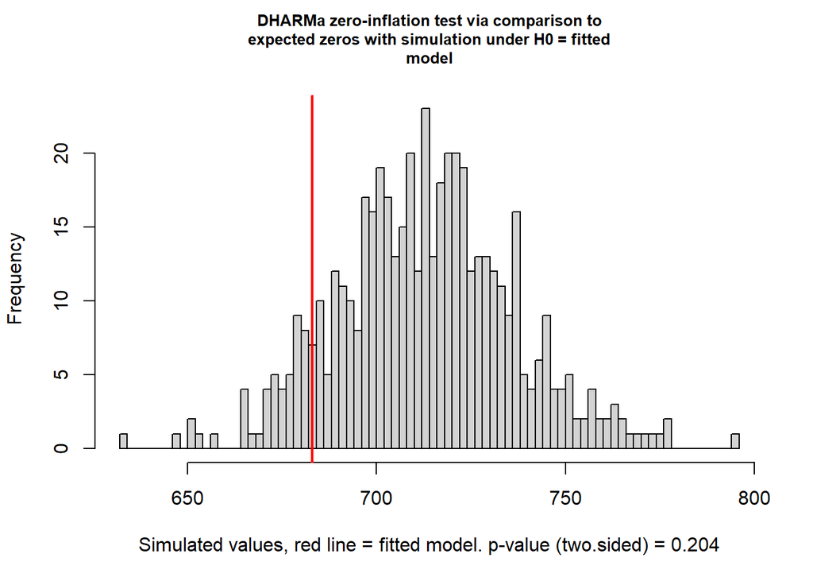

```
    DHARMa nonparametric dispersion test via sd of residuals fitted vs.
    simulated

data:  simulationOutput
dispersion = 1.1831, p-value < 2.2e-16
alternative hypothesis: two.sided
```

```
    DHARMa zero-inflation test via comparison to expected zeros with
    simulation under H0 = fitted model

data:  simulationOutput
ratioObsSim = 0.95735, p-value = 0.204
alternative hypothesis: two.sided
```

## Justify my choice for which model was carried forward

The hurdle negative binomial model was carried forward because it had the lowest AIC and BIC of the candidate models and reproduced the overall number of zeros well (observed/expected ratio = 0.998, *p* = 0.984). In contrast, ordinary NB2 continued to under predict zeros. The ZINB model also addressed the overall zero-count mismatch, but had higher AIC and BIC than the hurdle model.

The selected model nevertheless retained significant residual overdispersion (ratio = 1.148, *p* = 0.008) and its residuals differed significantly from the expected uniform distribution. The quantile diagnostic also issued a fitting warning, so its p-value was not relied upon. So, the hurdle model was the best-supported of the candidates considered, rather than a fully adequate description of the data. Later findings are interpreted with this limitation in mind.

# Part 6: Test and probe an interaction

## 6.1 State the prediction

I predict that the positive association between chronic conditions and physician visits will be stronger for people with private insurance than among those without it. Private insurance could reduce financial barriers to seeking care which would allow increases in healthcare needs to translate into greater use of physician services. This prediction concerns the interaction in the model’s count component. The zero component is kept unchanged.

## 6.2 Fit the interaction model

## 6.3 Test whether the interaction is needed

The additive and interaction models were compared using a likelihood-ratio test. The zero component was identical in both models, so this comparison tests the addition of the chronic conditions × insurance interaction in the count component.

Likelihood-Ratio Test of the Interaction

| Model | Df | AIC | BIC | logLik | deviance | Chisq | Chi Df | Pr(>Chisq) |
| --- | --- | --- | --- | --- | --- | --- | --- | --- |
| m_hurdle | 15 | 24330.41 | 24426.27 | -12150.20 | 24300.41 | NA | NA | NA |
| m_hurdle_int | 16 | 24332.07 | 24434.32 | -12150.03 | 24300.07 | 0.3409581 | 1 | 0.5592767 |

The likelihood-ratio comparison gave χ²(1) = 0.34, *p* = 0.559.

The interaction will be probed regardless of the significance of this test. Probing examines the association with chronic conditions within each insurance group and the differences between insurance groups at selected values of chronic conditions.

Adding the chronic conditions × insurance interaction did not significantly improve model fit. The estimated interaction was negative, which was the opposite of the predicted direction, but there was insufficient evidence that the count-component association between chronic conditions and physician visits differed by insurance status. AIC and BIC also favored the simpler additive model. The interaction model was still retained for probing, since this assignment requires this. This does not imply that it was preferred as the final model.

## 6.4 Plot predicted counts

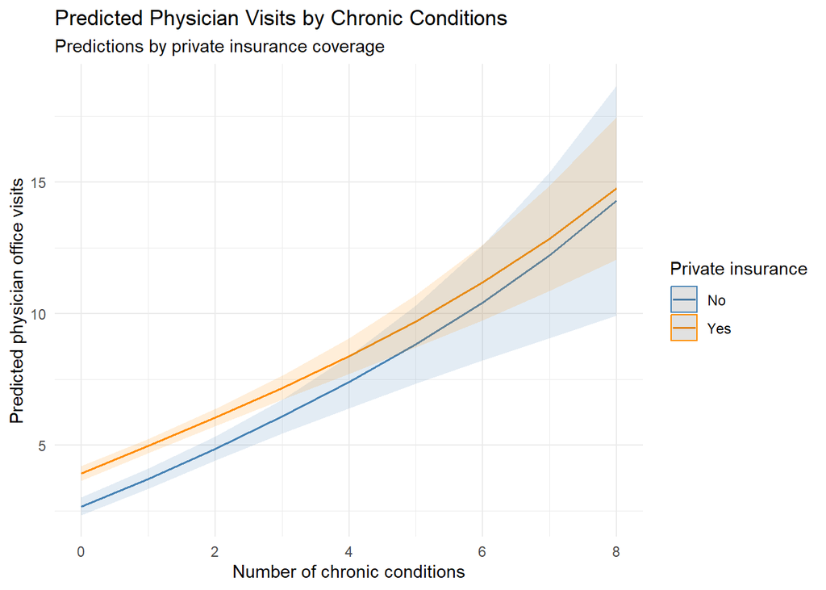

Predicted physician visits by chronic conditions and private insurance, incorporating both hurdle-model components.

The plot shows predicted physician visits across chronic conditions for respondents with and without private insurance. Predictions incorporate both the probability of having any visits and the expected positive visit count. Other predictors are held at their reference categories or means.

## 6.5 Probe the interaction

### Simple slopes of chronic conditions within insurance groups

```
 insurance chronic.trend     SE  df asymp.LCL asymp.UCL z.ratio p.value
 no                0.160 0.0247 Inf     0.111     0.208   6.462 <0.0001
 yes               0.143 0.0144 Inf     0.115     0.172   9.945 <0.0001

Results are averaged over the levels of: health, gender
Confidence level used: 0.95
```

### Compare the two slopes

```
 contrast estimate     SE  df asymp.LCL asymp.UCL z.ratio p.value
 no - yes   0.0164 0.0282 Inf   -0.0388    0.0717   0.583  0.5597

Results are averaged over the levels of: health, gender
Confidence level used: 0.95
```

The simple slopes describe the chronic-condition association within each insurance group on the count-component log scale. The slope comparison tests whether those two slopes differ. It does not test the interaction in the model’s zero component, which was kept unchanged.

The count-component slope for chronic conditions was positive in both insurance groups. However, the difference between the slopes was not statistically significant, which is consistent with the likelihood-ratio test of the interaction.

Because private insurance has only two levels, there are only two chronic-condition slopes to compare. With “no” as the reference category, the chronic × insurance interaction coefficient equals the slope for respondents with private insurance minus the slope for respondents without private insurance. The pairs() comparison uses the opposite order (no − yes), so its estimate has the opposite sign but the same standard error and two-sided p-value as the interaction coefficient’s Wald test. So, both Wald tests test the same null hypothesis, being that the two count-component log-scale slopes are equal.

The likelihood-ratio test also evaluates whether adding this interaction improves fit, but it uses a different testing method, so its p-value do not need to exactly match the Wald test’s p-value.

### Simple effects of insurance at selected chronic-condition values

```
chronic = 0.192:
 contrast estimate     SE  df asymp.LCL asymp.UCL z.ratio p.value
 no - yes   -0.158 0.0647 Inf    -0.285   -0.0317  -2.450  0.0143

chronic = 1.542:
 contrast estimate     SE  df asymp.LCL asymp.UCL z.ratio p.value
 no - yes   -0.136 0.0446 Inf    -0.224   -0.0489  -3.055  0.0022

chronic = 2.892:
 contrast estimate     SE  df asymp.LCL asymp.UCL z.ratio p.value
 no - yes   -0.114 0.0519 Inf    -0.216   -0.0124  -2.199  0.0279

Results are averaged over the levels of: health, gender
Results are given on the log (not the response) scale.
Confidence level used: 0.95
```

## 6.6 Report the simple effects in a table

Simple Effects of Private Insurance

Hurdle negative binomial count component

| Probing level | Chronic conditions | Contrast | Log contrast | SE | z | p |
| --- | --- | --- | --- | --- | --- | --- |
| -1 SD | 0.192 | no - yes | −0.158 | 0.065 | −2.450 | 0.014 |
| Mean | 1.542 | no - yes | −0.136 | 0.045 | −3.055 | 0.002 |
| +1 SD | 2.892 | no - yes | −0.114 | 0.052 | −2.199 | 0.028 |

Contrasts are No - Yes. Tests are computed on the count-component log scale. Each probing value is treated as a separate comparison family.

### Comparing emmeans results with the prediction plot

The emmeans analyses averaged over health and gender, whereas the ggeffects plot held non-focal categorical predictors at their reference levels. For comparisons on the same count-component log scale, these additive control-variable contributions cancel from the insurance contrast because they do not interact with insurance. However, the plotted predictions also combined the zero and count components, while the simple-effects analysis used only the count component. So, differences between the plot and these results reflect both the treatment of control variables and the model quantity being estimated. The count-component log contrasts should not be interpreted as contrasts in overall expected visits.

## 6.7 Interpret the interaction

There was insufficient evidence that the count-component association between chronic conditions and physician visits differed by private insurance status. Adding the interaction did not significantly improve fit, χ²(1) = 0.341, *p* = 0.559. The chronic-condition slopes were positive in both insurance groups, but their difference was not statistically significant.

Simple-effects comparisons indicated that respondents without private insurance had a lower count-component log parameter than those with insurance at low chronic conditions (log contrast = -0.158, *p* = 0.014), average chronic conditions (log contrast = -0.136, *p* = 0.002), and high chronic conditions (log contrast = -0.114, *p* = 0.028). These tests were not adjusted across the three probing values. The estimated log-scale difference was largest at the low probing value and smallest at the high value, but the non-significant interaction does not support a reliable change in the group difference as chronic conditions increase.

Overall, the results suggest an insurance-group difference in the count component instead of clear evidence of moderation. The original prediction of a stronger chronic-condition slope among respondents with private insurance was not supported. Still, interpretation remains cautious because the selected model retained residual-fit limitations.

# Part 7: Results and discussion

## 7.1 Results

Physician visits had a mean of 5.77 and a variance of 45.69, with 15.50% of respondents reporting no visits. The full Poisson model showed pronounced overdispersion (dispersion ratio = 7.246, p < .001) and under predicted the number of zeros (observed-to-simulated zero ratio = 14.906, p < .001). The negative-binomial model fit significantly better than the Poisson model, χ²(1) = 12129.08, p < .001. The NB2 dispersion test was no longer significant (dispersion ratio = 1.046, p = .392), but the model still under predicted zeros (observed-to-simulated zero ratio = 1.104, p = .004), supporting consideration of a separate zero component. Among the NB2, zero-inflated negative-binomial, and hurdle negative-binomial candidates, the hurdle model had the lowest BIC (24426.27), compared with 24436.63 for the zero-inflated model and 24521.03 for NB2, and was carried forward. Still, its residual diagnostics indicated remaining overdispersion (dispersion ratio = 1.148, p = .008) and residuals that differed significantly from the expected uniform distribution (D = 0.029, p < .001). So, The hurdle model was the best-supported candidate among those considered, instead of it being a fully adequate model.

In the selected additive hurdle negative-binomial model, greater numbers of chronic conditions (b = 0.148, 95% CI [0.123, 0.172], p < .001), poor health relative to the reference health category (b = 0.383, 95% CI [0.287, 0.478], p < .001), more years of schooling (b = 0.021, 95% CI [0.012, 0.030], p < .001), and private insurance (b = 0.130, 95% CI [0.045, 0.216], p = .003) were associated with higher log-scale count-component parameters, while adjusting for the other predictors. Excellent health was associated with a lower count-component parameter (b = -0.368, 95% CI [-0.501, -0.236], p < .001), whereas the female–male difference was not statistically significant (b = 0.056, 95% CI [-0.008, 0.121], p = .088). In the zero component, more chronic conditions (b = -0.558, 95% CI [-0.647, -0.470], p < .001), female gender (b = -0.401, 95% CI [-0.573, -0.230], p < .001), more schooling (b = -0.058, 95% CI [-0.082, -0.035], p < .001), and private insurance (b = -0.747, 95% CI [-0.944, -0.550], p < .001) were associated with lower odds of reporting zero physician visits. Excellent health was associated with higher odds of zero visits (b = 0.309, 95% CI [0.029, 0.588], p = .030), whereas poor health was not significantly associated with the odds of zero visits (b = -0.050, 95% CI [-0.363, 0.263], p = .754). Count-component coefficients describe the log-scale parameter of the truncated negative-binomial distribution, instead of effects on overall expected physician visits.

Adding the chronic conditions × private insurance interaction to the count component did not significantly improve model fit, χ²(1) = 0.341, p = .559. The count-component log-scale slope for chronic conditions was positive for respondents without private insurance (b = 0.160, 95% CI [0.111, 0.208], p < .001) and for those with private insurance (b = 0.143, 95% CI [0.115, 0.172], p < .001). Pointwise comparisons indicated lower count-component log parameters for “without private insurance” than respondents with private insurance at low chronic conditions (no − yes log contrast = -0.158, p = .014), average chronic conditions (log contrast = -0.136, p = .002), and high chronic conditions (log contrast = -0.114, p = .028). These comparisons were not adjusted across the three probing values. The estimated log-scale insurance difference was largest at the low probing value and smallest at the high probing value, but remained statistically significant at all three values. However, the non-significant interaction did not support a reliable difference between the chronic-condition slopes. The prediction of a stronger positive association among insured respondents was therefore not supported. So, the additive hurdle model was retained.

## 7.2 Discussion

The findings suggest that chronic conditions and self-perceived health were important correlates of physician visits. More chronic conditions were associated with a higher count-component parameter and lower odds of reporting no visits, suggesting associations with both whether respondents visited a physician and the positive-count process. Compared with average health, poor health was associated with a higher count-component parameter, whereas excellent health was associated with a lower count-component parameter and higher odds of reporting no visits. Together, these patterns are consistent with greater healthcare use among respondents with greater health needs. However, coefficient magnitudes should not be used alone to rank the importance of predictors because the predictors have different measurement scales.

Private insurance and education were also associated with both components of physician use. Respondents with private insurance and those with more schooling had higher count-component parameters and lower odds of zero visits, holding the other predictors constant. Women had lower odds of zero visits than men, but the count-component gender difference was not statistically significant. There was insufficient evidence that private insurance moderated the association between chronic conditions and the count component. Although insurance-group differences were detected at each selected chronic-condition value, those differences did not establish that the chronic-condition slopes differed between groups.

Many limitations should be considered when interpreting these findings. The analysis was observational, so the associations do not establish causal effects. The selected model adjusted only for the included predictors. Other factors, such as income and access to care, could contribute to the observed associations. The data concern older adults surveyed in the United States in the late 1980s, which limits generalization to younger populations and contemporary healthcare settings. Most importantly, although the hurdle negative-binomial model was the best-supported candidate among those considered, its residual diagnostics still indicated overdispersion and residuals that differed significantly from the expected uniform distribution. So, we should interpret its standard errors, confidence intervals, and p-values cautiously. The simple-effects tests were also pointwise comparisons without adjustment across the three probing values. Finally, count-component coefficients describe the truncated distribution’s log-scale parameter, not overall expected visits, which depend on both hurdle components.

## Disclosure of generative AI use

I used Perplexity to help generate, understand, and revise code for this assignment. This included assistance with model comparisons, residual diagnostics, interaction probing, tables, and inline reporting. I also used it to help explain and/or revise portions of the results, interpretation and discussion. The AI Prompt Appendix records the prompts used for this assignment.

## AI Prompt Appendix

The following prompts were submitted to Perplexity while completing this assignment. Prompts are reproduced verbatim and in chronological order.

### Prompt

```
this is what i got before adding the table and chart; # Select the six variables and set reference groups

data <- NMES1988 |>

dplyr::select(visits, chronic, health, gender, school, insurance) |>

mutate(

health = fct_relevel(health, "average"),

gender = fct_relevel(gender, "male"),

insurance = fct_relevel(insurance, "no")

)

head(data)
visits chronic  health gender school insurance
1      5       2 average   male      6       yes
2      1       2 average female     10       yes
3     13       4    poor female     10        no
4     16       2    poor   male      3       yes
5      3       2 average female      6       yes
6     17       5    poor female      7        no
str(data)
'data.frame':4406 obs. of  6 variables:
$ visits   : int  5 1 13 16 3 17 9 3 1 0 ...
$ chronic  : int  2 2 4 2 2 5 0 0 0 0 ...
$ health   : Factor w/ 3 levels "average","poor",..: 1 1 2 2 1 2 1 1 1 1 ...
..- attr(*, "contrasts")= num [1:3, 1:2] 1 0 0 0 0 1
.. ..- attr(*, "dimnames")=List of 2
.. .. ..$ : chr [1:3] "poor" "average" "excellent"
.. .. ..$ : chr [1:2] "poor" "excellent"
$ gender   : Factor w/ 2 levels "male","female": 1 2 2 1 2 2 2 2 2 2 ...
$ school   : int  6 10 10 3 6 7 8 8 8 8 ...
$ insurance: Factor w/ 2 levels "no","yes": 2 2 1 2 2 1 2 2 2 2 ...
summary(data)
visits          chronic            health        gender         school      insurance
Min.   : 0.000   Min.   :0.000   average  :3509   male  :1778   Min.   : 0.00   no : 985
1st Qu.: 1.000   1st Qu.:1.000   poor     : 554   female:2628   1st Qu.: 8.00   yes:3421
Median : 4.000   Median :1.000   excellent: 343                 Median :11.00
Mean   : 5.774   Mean   :1.542                                  Mean   :10.29
3rd Qu.: 8.000   3rd Qu.:2.000                                  3rd Qu.:12.00
Max.   :89.000   Max.   :8.000                                  Max.   :18.00

levels(data$health)
 "average"   "poor"      "excellent"
levels(data$gender)
 "male"   "female"
levels(data$insurance)
 "no"  "yes"
```

### Prompt

```
i got this but i want to understand this so i know what to do next (image.png)
```

### Prompt

```
Poisson comparisons:  summary(m0_pois)
Family: poisson  ( log )
Formula:          visits ~ 1
Data: data

      AIC       BIC    logLik -2*log(L)  df.resid
39720.3   39726.7  -19859.2   39718.3      4405

Conditional model:
Estimate Std. Error z value Pr(>|z|)
(Intercept) 1.753434   0.006269   279.7   <2e-16 ***

Signif. codes:  0 ‘’ 0.001 ‘’ 0.01 ‘*’ 0.05 ‘.’ 0.1 ‘ ’ 1

summary(m1_pois)
Family: poisson  ( log )
Formula:          visits ~ chronic
Data: data

      AIC       BIC    logLik -2*log(L)  df.resid
37546.9   37559.7  -18771.5   37542.9      4404

Conditional model:
Estimate Std. Error z value Pr(>|z|)
(Intercept) 1.409165   0.010124  139.19   <2e-16 ***
chronic     0.197902   0.004065   48.69   <2e-16 ***

Signif. codes:  0 ‘’ 0.001 ‘’ 0.01 ‘*’ 0.05 ‘.’ 0.1 ‘ ’ 1

summary(m2_pois)
Family: poisson  ( log )
Formula:          visits ~ chronic + health + gender + school + insurance
Data: data

      AIC       BIC    logLik -2*log(L)  df.resid
36597.0   36641.7  -18291.5   36583.0      4399

Conditional model:
Estimate Std. Error z value Pr(>|z|)
(Intercept)      1.244732   0.028415   43.81   <2e-16 ***
chronic          0.168793   0.004471   37.75   <2e-16 ***
healthpoor      -0.318204   0.017479  -18.20   <2e-16 ***
healthexcellent -0.697249   0.034267  -20.35   <2e-16 ***
genderfemale     0.108015   0.012943    8.35   <2e-16 ***
school           0.025754   0.001843   13.97   <2e-16 ***
insuranceyes     0.216007   0.016872   12.80   <2e-16 ***

Signif. codes:  0 ‘’ 0.001 ‘’ 0.01 ‘*’ 0.05 ‘.’ 0.1 ‘ ’ 1

pois_comparison
Data: data
Models:
m0_pois: visits ~ 1, zi=~0, disp=~1
m1_pois: visits ~ chronic, zi=~0, disp=~1
m2_pois: visits ~ chronic + health + gender + school + insurance, zi=~0, disp=~1
Df   AIC   BIC logLik deviance   Chisq Chi Df Pr(>Chisq)
m0_pois  1 39720 39727 -19859    39718
m1_pois  2 37547 37560 -18772    37543 2175.43      1  < 2.2e-16 ***
m2_pois  7 36597 36642 -18292    36583  959.92      5  < 2.2e-16 ***

Signif. codes:  0 ‘’ 0.001 ‘’ 0.01 ‘*’ 0.05 ‘.’ 0.1 ‘ ’ 1
```

### Prompt

```
to be specific i replaced the setup chunk in the load packages header. is this okay?
```

### Prompt

```
summary(m2_pois)
Family: poisson  ( log )
Formula:          visits ~ chronic + health + gender + school + insurance
Data: data

      AIC       BIC    logLik -2*log(L)  df.resid
36597.0   36641.7  -18291.5   36583.0      4399

Conditional model:
Estimate Std. Error z value Pr(>|z|)
(Intercept)      0.926527   0.025069   36.96   <2e-16 ***
chronic          0.168793   0.004471   37.75   <2e-16 ***
healthpoor       0.318205   0.017479   18.20   <2e-16 ***
healthexcellent -0.379045   0.030291  -12.51   <2e-16 ***
genderfemale     0.108014   0.012943    8.35   <2e-16 ***
school           0.025754   0.001843   13.97   <2e-16 ***
insuranceyes     0.216007   0.016872   12.80   <2e-16 ***

Signif. codes:  0 ‘’ 0.001 ‘’ 0.01 ‘*’ 0.05 ‘.’ 0.1 ‘ ’ 1

pois_comparison
Data: data
Models:
m0_pois: visits ~ 1, zi=~0, disp=~1
m1_pois: visits ~ chronic, zi=~0, disp=~1
m2_pois: visits ~ chronic + health + gender + school + insurance, zi=~0, disp=~1
Df   AIC   BIC logLik deviance   Chisq Chi Df Pr(>Chisq)
m0_pois  1 39720 39727 -19859    39718
m1_pois  2 37547 37560 -18772    37543 2175.43      1  < 2.2e-16 ***
m2_pois  7 36597 36642 -18292    36583  959.92      5  < 2.2e-16 ***

Signif. codes:  0 ‘’ 0.001 ‘’ 0.01 ‘*’ 0.05 ‘.’ 0.1 ‘ ’ 1
```

### Prompt

```
disp_pois

DHARMa nonparametric dispersion test via sd of residuals fitted vs. simulated

data:  simulationOutput
dispersion = 7.2457, p-value < 2.2e-16
alternative hypothesis: two.sided

zi_pois

DHARMa zero-inflation test via comparison to expected zeros with simulation under H0
= fitted model

data:  simulationOutput
ratioObsSim = 14.906, p-value < 2.2e-16
alternative hypothesis: two.sided
```

### Prompt

```
is it normal that my full poisson model shows overdispersion and more zeroes than it predicts?
```

### Prompt

```
the last thing i did was this ## Test for dispersion and excess zeros

{r}
#| label: poisson-diagnostic-tests

disp_pois <- testDispersion(res_pois)
zi_pois <- testZeroInflation(res_pois)

disp_pois
zi_pois
```

### Prompt

```
lrt_zinb
Data: data
Models:
m_nb: visits ~ chronic + health + gender + school + insurance, zi=~0, disp=~1
m_zinb: visits ~ chronic + health + gender + school + insurance, zi=~chronic + health + gender + school + insurance, disp=~1
Df   AIC   BIC logLik deviance  Chisq Chi Df Pr(>Chisq)
m_nb    8 24470 24521 -12227    24454
m_zinb 15 24341 24437 -12155    24311 143.14      7  < 2.2e-16 ***

Signif. codes:  0 ‘’ 0.001 ‘’ 0.01 ‘*’ 0.05 ‘.’ 0.1 ‘ ’ 1

zero_aic
df      AIC
m_nb      8 24469.91
m_zinb   15 24340.77
m_hurdle 15 24330.41
zero_bic
df      BIC
m_nb      8 24521.03
m_zinb   15 24436.63
m_hurdle 15 24426.27
```

### Prompt

```
ZINB: remaining checks
disp_zinb

DHARMa nonparametric dispersion test via sd of residuals fitted vs. simulated

data:  simulationOutput
dispersion = 1.1831, p-value < 2.2e-16
alternative hypothesis: two.sided

zi_zinb

DHARMa zero-inflation test via comparison to expected zeros with simulation under H0
= fitted model

data:  simulationOutput
ratioObsSim = 0.95735, p-value = 0.204
alternative hypothesis: two.sided

testQuantiles(res_zinb, plot = FALSE)

Test for location of quantiles via qgam

data:  res_zinb
p-value = 0.0004038
alternative hypothesis: both

Hurdle: uniformity and quantile checks
testUniformity(res_hurdle, plot = FALSE)

Asymptotic one-sample Kolmogorov-Smirnov test

data:  simulationOutput$scaledResiduals
D = 0.029434, p-value = 0.0009672
alternative hypothesis: two-sided

testQuantiles(res_hurdle, plot = FALSE)
Warning in newton(lsp = lsp, X = G$X, y = G$y, Eb = G$Eb, UrS = G$UrS, L = G$L,  :
Fitting terminated with step failure - check results carefully
Test for location of quantiles via qgam

data:  res_hurdle
p-value = 0.001523
alternative hypothesis: both
```

### Prompt

```
how do i confirm convergence checks
```

### Prompt

```
Help understand these summaries:  slopes_summary
insurance chronic.trend     SE  df asymp.LCL asymp.UCL z.ratio p.value
no                0.160 0.0247 Inf     0.111     0.208   6.462 <0.0001
yes               0.143 0.0144 Inf     0.115     0.172   9.945 <0.0001

Results are averaged over the levels of: health, gender
Confidence level used: 0.95

summary(slope_comparison, infer = c(TRUE, TRUE))
contrast estimate     SE  df asymp.LCL asymp.UCL z.ratio p.value
no - yes   0.0164 0.0282 Inf   -0.0388    0.0717   0.583  0.5597

Results are averaged over the levels of: health, gender
Confidence level used: 0.95
```

### Prompt

```
chronic_values
 0.1923565 1.5419882 2.8916199

simple_effects_summary
chronic = 0.192:
contrast estimate     SE  df asymp.LCL asymp.UCL z.ratio p.value
no - yes   -0.158 0.0647 Inf    -0.285   -0.0317  -2.450  0.0143

chronic = 1.542:
contrast estimate     SE  df asymp.LCL asymp.UCL z.ratio p.value
no - yes   -0.136 0.0446 Inf    -0.224   -0.0489  -3.055  0.0022

chronic = 2.892:
contrast estimate     SE  df asymp.LCL asymp.UCL z.ratio p.value
no - yes   -0.114 0.0519 Inf    -0.216   -0.0124  -2.199  0.0279

Results are averaged over the levels of: health, gender
Results are given on the log (not the response) scale.
Confidence level used: 0.95
```

### Prompt

```
what should i see from this # Outcome descriptives for the model-selection paragraph

print(visits_summary)
n     mean variance proportion_zero maximum
1 4406 5.774399 45.68712       0.1550159      89

Count-component results
print(

count_results |>

dplyr::select(term, estimate, conf.low, conf.high, p.value),

n = Inf,

width = Inf

)

A tibble: 7 × 5
  term            estimate conf.low conf.high  p.value
<chr>              <dbl>    <dbl>     <dbl>    <dbl>
1 (Intercept)       1.14    1.01       1.26   3.95e-70
2 chronic           0.148   0.123      0.172  2.07e-31
3 healthpoor        0.383   0.287      0.478  4.80e-15
4 healthexcellent  -0.368  -0.501     -0.236  4.83e- 8
5 genderfemale      0.0565 -0.00850    0.121  8.85e- 2
6 school            0.0212  0.0121     0.0303 4.79e- 6
7 insuranceyes      0.130   0.0452     0.216  2.71e- 3

Zero-component results
print(

zero_results |>

dplyr::select(term, estimate, conf.low, conf.high, p.value),

n = Inf,

width = Inf

)

A tibble: 7 × 5
  term            estimate conf.low conf.high  p.value
<chr>              <dbl>    <dbl>     <dbl>    <dbl>
1 (Intercept)       0.327    0.0460    0.608  2.26e- 2
2 chronic          -0.558   -0.647    -0.470  2.79e-35
3 healthpoor       -0.0500  -0.363     0.263  7.54e- 1
4 healthexcellent   0.309    0.0294    0.588  3.03e- 2
5 genderfemale     -0.401   -0.573    -0.230  4.33e- 6
6 school           -0.0582  -0.0817   -0.0348 1.13e- 6
7 insuranceyes     -0.747   -0.944    -0.550  1.14e-13
```

### Prompt

```
DHARMa::testDispersion(res_hurdle, plot = FALSE)

DHARMa nonparametric dispersion test via sd of residuals fitted vs. simulated

data:  simulationOutput
dispersion = 1.1477, p-value = 0.008
alternative hypothesis: two.sided

DHARMa::testUniformity(res_hurdle, plot = FALSE)

Asymptotic one-sample Kolmogorov-Smirnov test

data:  simulationOutput$scaledResiduals
D = 0.029434, p-value = 0.0009672
alternative hypothesis: two-sided
```